## Use R to Analize data ‘savings’ from the **faraway** library

## Savings rates in 50 countries

The savings data frame has 50 rows and 5 columns. The data is averaged over the period 1960-1970. This data frame contains the following columns:

- sr – personal saving divided by disposable income
- pop15 – percent population under age of 15
- pop75 – percent population over age of 75
- dpi – per-capita disposable income in dollars
- ddpi – percent growth rate of dpi

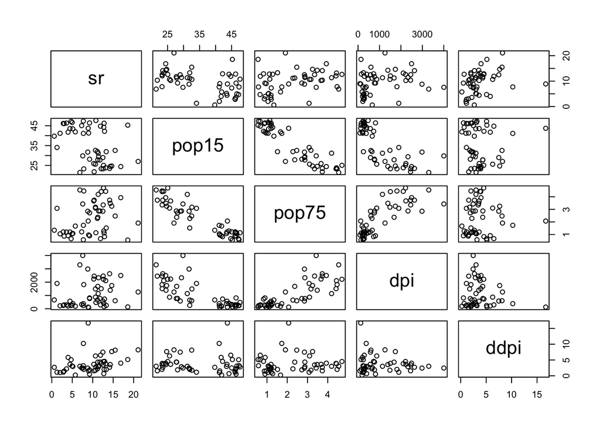

```r
library(faraway)
?savings

pairs(savings)
```

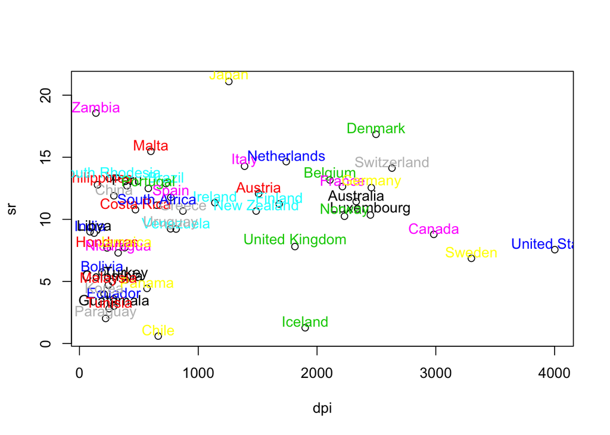

```r
attach(savings)
country=dimnames(savings)[[1]]
plot(dpi, sr)
text(dpi+0.5, sr+0.5, country, col=1:50)
```

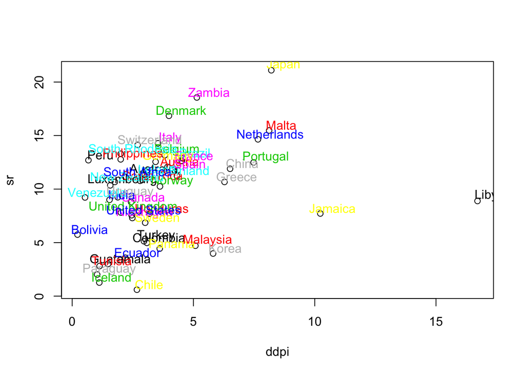

```r
plot(ddpi, sr)
text(ddpi+0.5, sr+0.5, country, col=1:50)
```

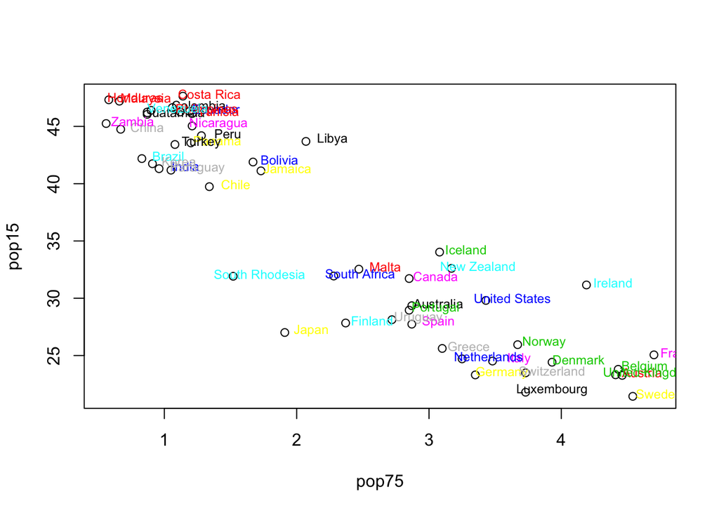

```r
plot(pop75, pop15)
text(pop75+0.2, pop15+0.2, country, col=1:50, cex=0.75)
```

## Fit Linear Regression Models

Older people tend to save more. The question is whether ‘sr’ is higher for counties with higher ‘pop75’? We fit a SLR with sr as the response and pop75 as the predictor.

```r
summary(lm(sr ~ pop75,data=savings))
```

```
##
## Call:
## lm(formula = sr ~ pop75, data = savings)
##
## Residuals:
##     Min      1Q  Median      3Q     Max
## -9.2657 -3.2295  0.0543  2.3336 11.8498
##
## Coefficients:
##             Estimate Std. Error t value Pr(>|t|)
## (Intercept)   7.1517     1.2475   5.733  6.4e-07 ***
## pop75         1.0987     0.4753   2.312   0.0251 *
## ---
## Signif. codes:  0 '***' 0.001 '**' 0.01 '*' 0.05 '.' 0.1 ' ' 1
##
## Residual standard error: 4.294 on 48 degrees of freedom
## Multiple R-squared:  0.1002, Adjusted R-squared:  0.08144
## F-statistic: 5.344 on 1 and 48 DF,  p-value: 0.02513
```

Next, let’s fit a MLR with all four predictors including pop75.

```r
fullmodel=lm(sr~pop15+pop75+dpi+ddpi, data=savings)
summary(fullmodel)
```

```
##
## Call:
## lm(formula = sr ~ pop15 + pop75 + dpi + ddpi, data = savings)
##
## Residuals:
##     Min      1Q  Median      3Q     Max
## -8.2422 -2.6857 -0.2488  2.4280  9.7509
##
## Coefficients:
##               Estimate Std. Error t value Pr(>|t|)
## (Intercept) 28.5660865  7.3545161   3.884 0.000334 ***
## pop15       -0.4611931  0.1446422  -3.189 0.002603 **
## pop75       -1.6914977  1.0835989  -1.561 0.125530
## dpi         -0.0003369  0.0009311  -0.362 0.719173
## ddpi         0.4096949  0.1961971   2.088 0.042471 *
## ---
## Signif. codes:  0 '***' 0.001 '**' 0.01 '*' 0.05 '.' 0.1 ' ' 1
##
## Residual standard error: 3.803 on 45 degrees of freedom
## Multiple R-squared:  0.3385, Adjusted R-squared:  0.2797
## F-statistic: 5.756 on 4 and 45 DF,  p-value: 0.0007904
```

While pop75 is a significant predictor for sr in SLR with a positve coefficient, the coefficient estimate for pop75 in MLR is no longer significant and is even negative.

How should we interprete the coefficient estimate for pop75 in SLR and the one in MLR?

Does it make sense for the SLR to suggest that pop75 has a positive effect on sr, while MLR suggests the opposite? Such seemingly contradictory statements are quite common when predictors are correlated.

```r
# Lets look at the correlation matrix
cor(savings[,-1])
```

```
##             pop15       pop75        dpi        ddpi
## pop15  1.00000000 -0.90847871 -0.7561881 -0.04782569
## pop75 -0.90847871  1.00000000  0.7869995  0.02532138
## dpi   -0.75618810  0.78699951  1.0000000 -0.12948552
## ddpi  -0.04782569  0.02532138 -0.1294855  1.00000000
```

## How to handle rank defficiency?

Sometimes, we may have redundant predictors, i.e., one predictor is equal to a linear combination of some other predictors. Then the design matrix X is not of full rank. The consequence is that the inverse of (X’X) does not exist, so we cannot compute the LS estimate beta-hat.

Suppose we create a new variable which measures the percentage of poeple between age 15 and 75, i.e., pop.mid = 1 - pop15 - pop75, then re-run the regression with 5 predictors.

```r
newsavings = savings
newsavings[, "pop.mid"] = 1 - savings$pop15 - savings$pop75
newfullmodel = lm(sr ~ ., data=newsavings)
summary(newfullmodel)
```

```
##
## Call:
## lm(formula = sr ~ ., data = newsavings)
##
## Residuals:
##     Min      1Q  Median      3Q     Max
## -8.2422 -2.6857 -0.2488  2.4280  9.7509
##
## Coefficients: (1 not defined because of singularities)
##               Estimate Std. Error t value Pr(>|t|)
## (Intercept) 28.5660865  7.3545161   3.884 0.000334 ***
## pop15       -0.4611931  0.1446422  -3.189 0.002603 **
## pop75       -1.6914977  1.0835989  -1.561 0.125530
## dpi         -0.0003369  0.0009311  -0.362 0.719173
## ddpi         0.4096949  0.1961971   2.088 0.042471 *
## pop.mid             NA         NA      NA       NA
## ---
## Signif. codes:  0 '***' 0.001 '**' 0.01 '*' 0.05 '.' 0.1 ' ' 1
##
## Residual standard error: 3.803 on 45 degrees of freedom
## Multiple R-squared:  0.3385, Adjusted R-squared:  0.2797
## F-statistic: 5.756 on 4 and 45 DF,  p-value: 0.0007904
```

Of course, when X has rank deficiency, we cannot discuss parameter estimation, since the LS estimates are not longer unique — there are many many equally good estimates of beta which give us the same RSS.

But if we just care about prediction, then rank deficiency doesn’t bring us any trouble. You’ll find the fitted values from the two models, with/without pop.mid, are the same.

```r
cbind(fullmodel$fitted[1:5], newfullmodel$fitted[1:5])
```

```
##                [,1]      [,2]
## Australia 10.566420 10.566420
## Austria   11.453614 11.453614
## Belgium   10.951042 10.951042
## Bolivia    6.448319  6.448319
## Brazil     9.327191  9.327191
```